# Assignment 2

Jongmin Lim

By Jongmin Lim BCB420

### Assignment 1

### Title

**Patient-Specific iPSC-Derived Astrocytes Contribute to Non-Cell-Autonomous Neurodegeneration in Parkinson’s Disease**

### Backgrounds

This study is try to investigate does Parkinson’s disease (PD) -specific iPSC-derived astrocyte cause morphological signs of neurodegeneration and abnormal, astrocyte-derived α-synuclein accumulation to ventral midbrain dopaminergic neurons (vmDAns). They hypothesize that patient-specific iPSC-derived astrocyte will cause abnormal morphological sign of neurodenerationto vmDAns. They further demonstrate the how does chaperon-mediated autophagy (CMA) related to this phenomenone and enhancement of CMA can protect PD astrocyte and vmAns via the clearance of α-synucleinaccumulation that can lead to neurodegeneration.

### Dataset

This dataset is RNAseq expression of astrocyte, iPSC, PD-iPSC, PD-derived astrocyte, and derived-astrocyte. The purpose of this database is to validate astrocyte cell type identity by expression of astrocyte specific gene. This is important since they need to get correct cell type to proceed to experiment. This dataset is interesting to me because it shows the different in RNA expression between iPSC, derived-astrocyte, and astrocyte, which indicates how close can we derive one cell type to other type of cell. RNA expression data can be use to improve the qualitied of derived cell by using more specific transcription factors to get more closer to expected type of cell. By able to derived iPSC into multiple type of cells, we can use this type of techinique in multiple application, such as organoid, therapy, sample for experiment.

**Collecting Data**

- PD-iPSC has been collected from 3 PD patients.
- iPSC and astrocyte has been collected from 3 healthy donors.
- By using Retrovirus, they differentiated PD-iPSC and iPSC into derived PD-astrocyte and derived astrocyte correspondingly.

**Control Condition**  
Need to compare the RNA expression between derived-astrocyte to iPSC and astrocyte

- Healthy donor’s iPSC
- PD-iPSC
- Astrocyte

**Test conditions**

These cells that they will use for experiment. - PD-derived astrocyte - Derived-astrocyte

### GSE

**Install require packages**

```r
if (!requireNamespace("colorRamps", quietly=TRUE)) {
  install.packages("colorRamps")
}
if (!requireNamespace("doBy", quietly=TRUE)) {
  install.packages("doBy")
}
if (!requireNamespace("gprofiler2", quietly=TRUE)) {
  install.packages("gprofiler2")
}
```

**Load library**

```r
#List of package that need to be active for this project
library(GEOmetadb)
library(knitr)
library(tidyr)
library(biomaRt)
library(edgeR)
library(BiocGenerics)
library(ComplexHeatmap)
library(circlize)
library(colorRamps)
library(dplyr)
library(doBy)
library(gprofiler2)
library(kableExtra)
library(limma)
```

**Create child document**

**Information about Platform GSE**

```r
#GEO description of of my dataset
gse <- getGEO("GSE116124", GSEMatrix=FALSE)
kable(data.frame(head(Meta(gse))), format = "html")
```

| contact_address | contact_city | contact_country | contact_email | contact_institute | contact_laboratory |
| --- | --- | --- | --- | --- | --- |
| Avinguda Gran Via, 199-203 | Hospitalet de Llobregat (Barcelona) | Spain | meritxell.pons@ub.edu | Institute of Biomedicine of the University of Barcelona (IBUB) | Neural Commitment and Differentiation Lab |

**More Information about dataset**

```r
current_gpl <- names(GPLList(gse))[1]
current_gpl_info <- Meta(getGEO(current_gpl))
```

**Platform Title:** Illumina HiSeq 2000 (Homo sapiens)  
**Original submission date:** Nov 02 2010  
**Last update date:** Mar 27 2019  
**Organism:** Homo sapiens  
**No. of GEO datasets that use this technology:** 7848  
**No. of GEO samples that use this technology:** 121152

### Get and Clean Data

**Get the expression Data**

```r
#Asign the file
sfiles = getGEOSuppFiles('GSE116124')
fnames = rownames(sfiles)
cell_exp = read.delim(fnames[1], header=TRUE, check.names = FALSE)
```

**Load first 15 row of dataset with html table format**

```r
#Load the dataset with html table format
kable(cell_exp[1:15,1:5], format = "html")
```

| id_gene,gene_name,gene_type | AD5607 | AD5609 | AD5610 | AD5611 |
| --- | --- | --- | --- | --- |
| ENSG00000223972.5,DDX11L1,transcribed_unprocessed_pseudogene | 0 | 0 | 0 | 0 |
| ENSG00000227232.5,WASH7P,unprocessed_pseudogene | 356 | 288 | 110 | 130 |
| ENSG00000278267.1,MIR6859-1,miRNA | 0 | 0 | 0 | 0 |
| ENSG00000243485.5,MIR1302-2HG,lincRNA | 4 | 6 | 0 | 0 |
| ENSG00000284332.1,MIR1302-2,miRNA | 0 | 0 | 0 | 0 |
| ENSG00000237613.2,FAM138A,lincRNA | 0 | 0 | 0 | 0 |
| ENSG00000268020.3,AL627309.6,unprocessed_pseudogene | 0 | 0 | 0 | 0 |
| ENSG00000240361.2,OR4G11P,transcribed_unprocessed_pseudogene | 0 | 2 | 0 | 0 |
| ENSG00000186092.5,OR4F5,protein_coding | 0 | 1 | 0 | 0 |
| ENSG00000238009.6,AL627309.1,lincRNA | 10 | 16 | 28 | 17 |
| ENSG00000239945.1,AL627309.3,lincRNA | 6 | 0 | 26 | 10 |
| ENSG00000233750.3,CICP27,processed_pseudogene | 117 | 45 | 39 | 63 |
| ENSG00000268903.1,AL627309.7,processed_pseudogene | 575 | 590 | 19 | 26 |
| ENSG00000269981.1,AL627309.8,processed_pseudogene | 107 | 127 | 0 | 9 |
| ENSG00000239906.1,AL627309.2,antisense_RNA | 1 | 8 | 0 | 0 |

**ID_gene,gene_name, and gene_type are in one colums. Need to divide into first 3 columns**

```r
#Separate the first column in to 3 total based on the id, name,and type of gene
cell_exp <- separate(cell_exp, col = "id_gene,gene_name,gene_type", into = c("id_gene", "gene_name", "gene_type"), sep = "\\,")

#Assign the column names
colnames(cell_exp) <- list("ensembl_gene_id", "gene_name", "gene_type",
                           "iPSC.A", "iPSC.B",
                           "hASTRO.E", "hASTRO.E",
                           "hASTRO.A","hASTRO.B",
                           "hASTRO.C", "hASTRO.D",
                           "iPSC.C", "iPSC.D")
#Remove unessacry data for this comparison
cell_exp <- cell_exp[,-(6:7)]
#Load first 15 row of dataset with html table format
kable(cell_exp[1:15,1:5], type="html") %>%
  kable_styling(bootstrap_options = "striped", full_width = F)
```

| ensembl_gene_id | gene_name | gene_type | iPSC.A | iPSC.B |
| --- | --- | --- | --- | --- |
| ENSG00000223972.5 | DDX11L1 | transcribed_unprocessed_pseudogene | 0 | 0 |
| ENSG00000227232.5 | WASH7P | unprocessed_pseudogene | 356 | 288 |
| ENSG00000278267.1 | MIR6859-1 | miRNA | 0 | 0 |
| ENSG00000243485.5 | MIR1302-2HG | lincRNA | 4 | 6 |
| ENSG00000284332.1 | MIR1302-2 | miRNA | 0 | 0 |
| ENSG00000237613.2 | FAM138A | lincRNA | 0 | 0 |
| ENSG00000268020.3 | AL627309.6 | unprocessed_pseudogene | 0 | 0 |
| ENSG00000240361.2 | OR4G11P | transcribed_unprocessed_pseudogene | 0 | 2 |
| ENSG00000186092.5 | OR4F5 | protein_coding | 0 | 1 |
| ENSG00000238009.6 | AL627309.1 | lincRNA | 10 | 16 |
| ENSG00000239945.1 | AL627309.3 | lincRNA | 6 | 0 |
| ENSG00000233750.3 | CICP27 | processed_pseudogene | 117 | 45 |
| ENSG00000268903.1 | AL627309.7 | processed_pseudogene | 575 | 590 |
| ENSG00000269981.1 | AL627309.8 | processed_pseudogene | 107 | 127 |
| ENSG00000239906.1 | AL627309.2 | antisense_RNA | 1 | 8 |

### Modify the id_gene

```r
#Need to remove decimal point so I can map identifiersd without version
cell_exp$ensembl_gene_id  <- gsub(pattern = "\\.\\d+$", replacement = "", x = cell_exp$ensembl_gene_id, ignore.case = TRUE)
```

**Dimension of dataset**

```r
#Look at the dimension of current dataset
#58347 genes and 8 out of 11 are samples. 3 rows are id, name, and type of gene
dim(cell_exp)
```

```
## [1] 58347    11
```

**Define the group**

- Cell type with corresponding GSM number can be find in this link and gse [link](https://www.ncbi.nlm.nih.gov/geo/query/acc.cgi?acc=GSE116124)
- Divide into 2 groups since there is 2 replicates
- Open the gse file directly and identify the cell type with correspoding sample code (AD####).

```r
#Define the group
samples <- data.frame(
           lapply(colnames(cell_exp)[4:ncol(cell_exp)],
           FUN=function(x){
             unlist(strsplit(x, split = "\\."))[c(1,2)]})) #Separate based on "."
#Separate columns based on cell type and patient
colnames(samples) <- colnames(cell_exp)[4:ncol(cell_exp)]
rownames(samples) <- c("cell_type", "patient")
samples <- data.frame(t(samples))
samples
```

```
##          cell_type patient
## iPSC.A        iPSC       A
## iPSC.B        iPSC       B
## hASTRO.A    hASTRO       A
## hASTRO.B    hASTRO       B
## hASTRO.C    hASTRO       C
## hASTRO.D    hASTRO       D
## iPSC.C        iPSC       C
## iPSC.D        iPSC       D
```

### Filtering

- Y-RNA appear more than once in the row
- According from lecture, don’t need to filter out at this point

```r
#Summarize the count of each gene
#Use gene name to make sure there is no duplicate
summarized_gene_counts <- sort(table(cell_exp$gene_name), decreasing = TRUE)
#Output that has greater than 1 count
kable(summarized_gene_counts[which(summarized_gene_counts>1)[1:10]], format = "html")
```

| Var1 | Freq |
| --- | --- |
| Y_RNA | 758 |
| Metazoa_SRP | 170 |
| U3 | 51 |
| U6 | 37 |
| uc_338 | 36 |
| snoU13 | 31 |
| SNORA31 | 27 |
| SNORA70 | 27 |
| U8 | 22 |
| U2 | 21 |

**Filtering the gene with low counts**

```r
#Change to count per million
cpms = cpm(cell_exp[,4:11])
#Set the rowname of first colum of cell_exp dataset
rownames(cpms) <- cell_exp[,1]
#Remove 1 or lower read per million.
#Keep the replicate group that equal or greater than 2
keep = rowSums(cpms >1) >=2
cell_exp_filtered = cell_exp[keep,]
#Show the dimension of dataset after filteration
dim(cell_exp_filtered)
```

```
## [1] 16993    11
```

- 58347-16993 = 41354 outliers were removed

```r
#Summarize the count
summarized_gene_counts_filtered <- sort(table(cell_exp_filtered$gene_name), decreasing = TRUE)
#Output greater than 1
kable(summarized_gene_counts_filtered[which(summarized_gene_counts_filtered>1)[1:10]], format = "html")
```

| Var1 | Freq |
| --- | --- |
| AKAP17A | 2 |
| ASMTL | 2 |
| BMS1P4 | 2 |
| CD99 | 2 |
| CD99P1 | 2 |
| CDR1 | 2 |
| COG8 | 2 |
| DHRSX | 2 |
| EMG1 | 2 |
| GTPBP6 | 2 |

-Many duplicates genes filtered out

### Normalization

- There are many variation that happen while collecting the data
- Normalization remove tehcnicla variation and focus on biological variation, which is what we want to know
- Sampling of set of genes and associating some metric with that sampling
- There are many types of well characterized distribution, such as normal distribution and bimodal distribution
- I will use boxplot and density plot to normalize and visulize the data

**Boxplot of dataset**

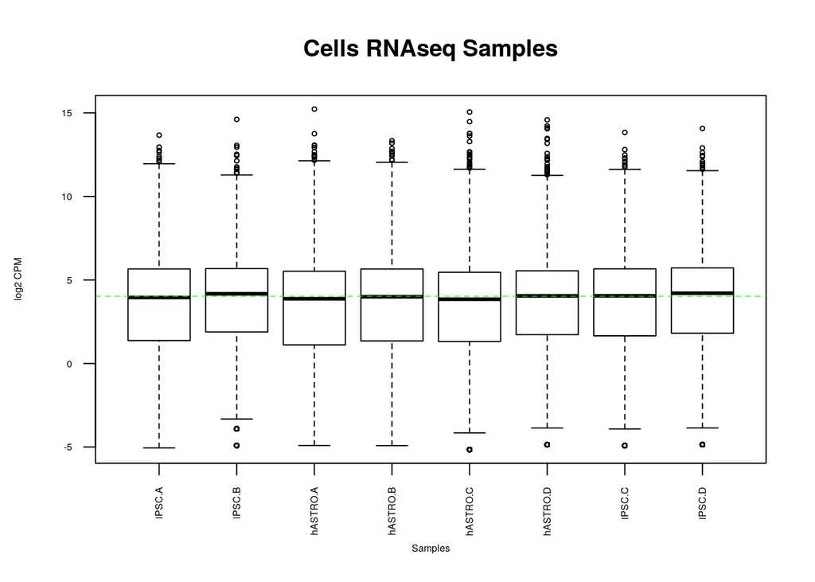

```r
#Calculate log to filitered data
data2plot <- log2(cpm(cell_exp_filtered[,4:11]))
#Plot the boxplot based on data2plot
boxplot(data2plot, xlab = "Samples", ylab = "log2 CPM",
        las = 2, cex = 0.5, cex.lab = 0.5,
        cex.axis = 0.5, main = "Cells RNAseq Samples")
#Draw the median of each box plot
abline(h = median(apply(data2plot, 2, median)), col = "green", lwd = 0.6, lty = "dashed")
```

**Density plot**

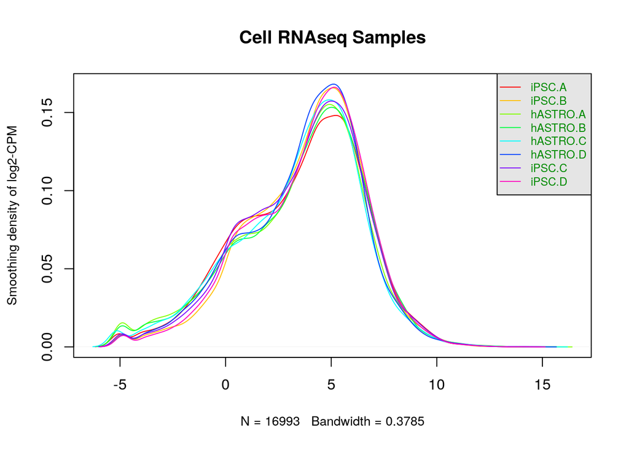

```r
#Calculate the data with log and set upt for density plot
counts_density <- apply(log2(cpm(cell_exp_filtered[, 4:11])), 2, density)
#Calculate the limits across all the samples
xlim <- 0; ylim <- 0
for (i in 1:length(counts_density)){
  xlim <- range(c(xlim, counts_density[[i]]$x));    #x limit
  ylim <- range(c(ylim, counts_density[[i]]$y))     #y limit
}
cols <- rainbow(length(counts_density))             #color
ltys <- rep(1, length(counts_density))              #line style
#plot the first density plot ot initialize the plot
plot(counts_density[[1]], xlim=xlim, ylim=ylim, type="n",
     ylab="Smoothing density of log2-CPM", main = "Cell RNAseq Samples", cex.lab = 0.85)
#plot each line
for (i in 1:length(counts_density)) lines(counts_density[[i]], col=cols[i], lty=ltys[i])
#create legend
legend("topright", colnames(data2plot),
       col=cols, lty=ltys, cex=0.75,
       border = "blue", text.col = "green4",
       merge = TRUE, bg = "gray90")
```

**M vs A plot**

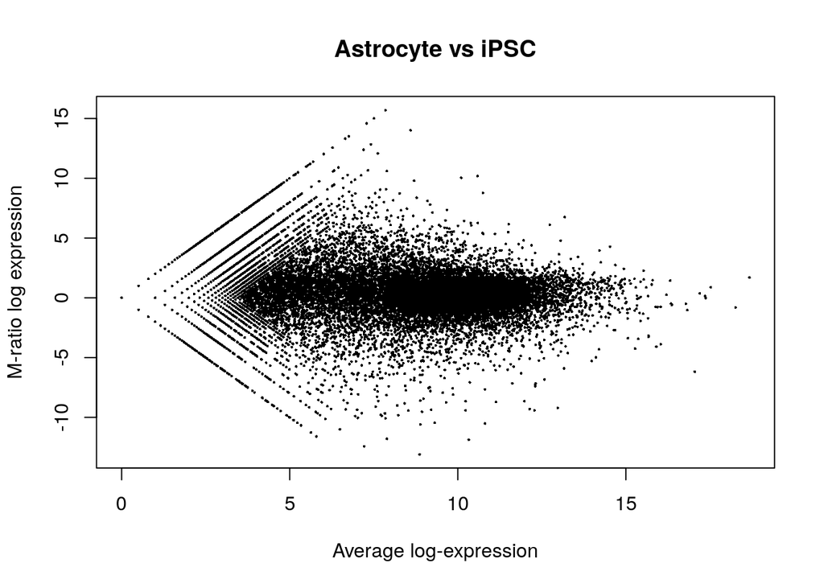

```r
#Trimmed mean of m-values (d) method, based on hypothesis that most genes are not differentially expressed
#Compare between iPSC and asctrocyte
limma::plotMA(log2(cell_exp[, 5:6]), ylab = "M-ratio log expression", main = "Astrocyte vs iPSC")
```

**Applying TMM to dataset**

- Trimmed mean: average after remove upper and lower percentage of the data points
- By default, 30% of the M values and 5% of the A values
- TMM compare each sample to a reference
- Data does not need to be modified prior to normalization

```r
#Convert data.frame to matrix
#Need to make sure that use filtered count and matrix
filtered_data_matrix <- as.matrix(cell_exp_filtered[, 4:11])
rownames(filtered_data_matrix) <- cell_exp_filtered$ensembl_gene_id#Add rownames

#Define group as cell type to compare
tmMreq = DGEList(counts = filtered_data_matrix, group = samples$cell_type)

#Calculate normalization factors
tmMreq = calcNormFactors(tmMreq)

#Get normalized data
normalized_counts <- cpm(tmMreq)
```

**Two density graphs**

- Comparison between normalized and not normalized data with density graphs
- There is some difference between two plots
- Each line in normalized data are closer together compare to not normalized data except hole that located in around range 0 get bigger.
- Location of lines in normalized data are different compare to not normalized data

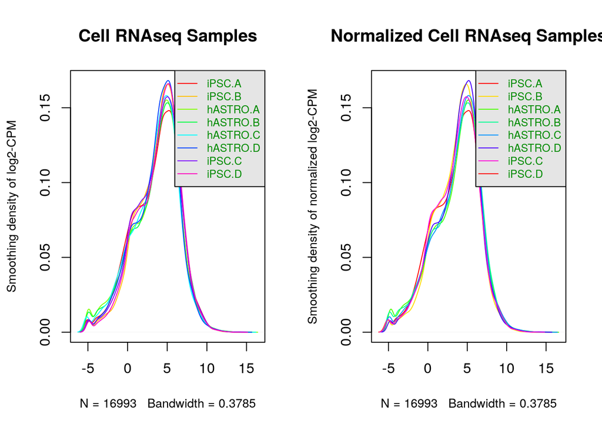

```r
#Separate the area to load 2 graphs
par(mfrow= c(1,2))

#Not normalized data (left)
counts_density <- apply(log2(cpm(cell_exp_filtered[, 4:11])), 2, density)
#Calculate the limits across all the samples
xlim <- 0; ylim <- 0
for (i in 1:length(counts_density)){
  xlim <- range(c(xlim, counts_density[[i]]$x));
  ylim <- range(c(ylim, counts_density[[i]]$y))
}
cols <- rainbow(length(counts_density))
ltys <- rep(1, length(counts_density))
#plot the first density plot to initialize the plot
plot(counts_density[[1]], xlim=xlim, ylim=ylim, type="n",
     ylab="Smoothing density of log2-CPM", main = "Cell RNAseq Samples", cex.lab = 0.85)
#plot each line
for (i in 1:length(counts_density)) lines(counts_density[[i]], col=cols[i], lty=ltys[i])
#create legend
legend("topright", colnames(data2plot),
       col=cols, lty=ltys, cex=0.75,
       border = "blue", text.col = "green4",
       merge = TRUE, bg = "gray90")

#Normalized data (right)
normalized_density <- apply(log2(normalized_counts[, 1:7]), 2, density)
#Calculate the limits across all the samples
xlim <- 0; ylim <- 0
for (i in 1:length(normalized_density)){
  xlim <- range(c(xlim, normalized_density[[i]]$x));
  ylim <- range(c(ylim, normalized_density[[i]]$y))
}
cols <- rainbow(length(normalized_density))
ltys <- rep(1, length(normalized_density))
#plot the first density plot ot initialize the plot
plot(normalized_density[[1]], xlim=xlim, ylim=ylim, type="n",
     ylab="Smoothing density of normalized log2-CPM", main = "Normalized Cell RNAseq Samples", cex.lab = 0.85)
#plot each line
for (i in 1:length(normalized_density)) lines(normalized_density[[i]], col=cols[i], lty=ltys[i])
#create legend
legend("topright", colnames(data2plot),
       col=cols, lty=ltys, cex=0.75,
       border = "blue", text.col = "green4",
       merge = TRUE, bg = "gray90")
```

**Two boxplots**

- Comparison between normalized and not normalized data with box plots
- There is some difference between two plots
- Median of each samples are more equal to each other in normalized box plots.
- I don’t think interquartile range changed

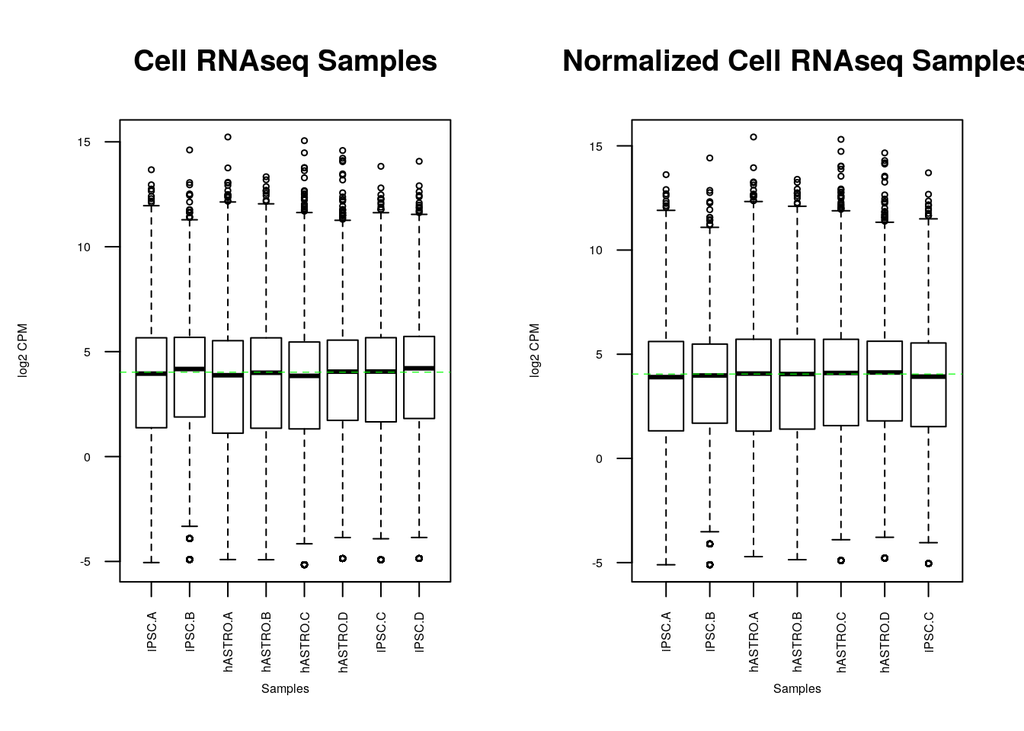

```r
#Separate the area to load 2 graphs
par(mfrow= c(1,2))

#Not normalized boxplot
data2plot <- log2(cpm(cell_exp_filtered[,4:11]))
boxplot(data2plot, xlab = "Samples", ylab = "log2 CPM",
        las = 2, cex = 0.5, cex.lab = 0.5,
        cex.axis = 0.5, main = "Cell RNAseq Samples")
#draw the median of each box plot
abline(h = median(apply(data2plot, 2, median)), col = "green", lwd = 0.6, lty = "dashed")

#Normalized boxplot
data2plot <- log2(normalized_counts[,1:7])
boxplot(data2plot, xlab = "Samples", ylab = "log2 CPM",
        las = 2, cex = 0.5, cex.lab = 0.5,
        cex.axis = 0.5, main = "Normalized Cell RNAseq Samples")
#draw the median of each box plot
abline(h = median(apply(data2plot, 2, median)), col = "green", lwd = 0.6, lty = "dashed")
```

**MDS plot**

- MDS plot represent the distance between samples
- Closer distence mean similar in RNAseq
- iPSC cluster together. Even if they come from different patient, because of gaining pluripotency by force to express specific genes lead to increasing similarity
- Astrocyte (hASTRO) are cluster in 2 but seperated. This might happen because one group should be patient with Parkinson disease while another group is without Parkinson disease

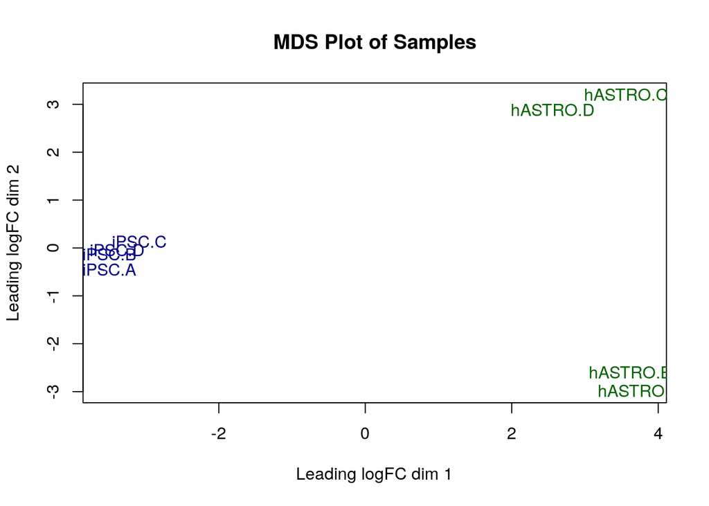

```r
#MDS plot to see the distance between samples
plotMDS(tmMreq, labels=rownames(samples),
        main = "MDS Plot of Samples",
        col = c("darkgreen", "darkblue")[factor(samples$cell_type)])
```

**Estimate common and tagwise dispersion**

- Dispersion describe how much variance deviated from teh mean
- Specific to edgeR and used downstream when calculating differential expression
- Can estimate common and tagwise disperison
- Common dispersion calculate common disperions values
- Tagwise dispersion calculate gene-specific disterpsion

```r
#Estimate common and tagwise dispersion
model_design <- model.matrix(~ samples$patient)
dispersion <- estimateDisp(tmMreq, model_design)
```

**Plot BCV**

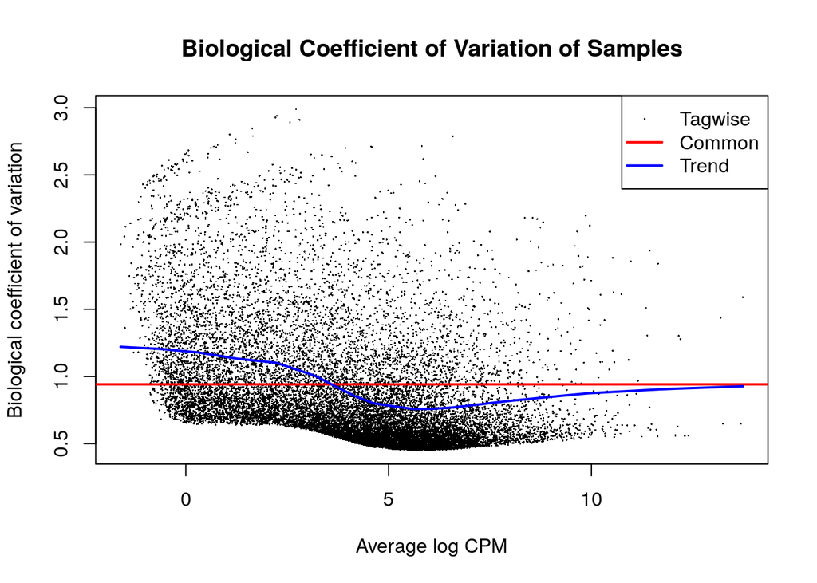

```r
#Plot BCV with sample
plotBCV(dispersion, col.tagwise = "black", col.common = "red", main = "Biological Coefficient of Variation of Samples")
```

**Plot mean variable relationship**

- Gray dots are raw varaince of the counts
- Blue dots are estimated varaince by using tagwise dispersion
- Red x are variance binned common dispersion
- Dark red x are average of the raw varaince of each bin of genes
- Blue line is mean variance related to negative binomial distribution with common dispersion
- All the line, x, and dots are in same trend within NBline, which is good
- I got information from this webpage [link](https://www.rdocumentation.org/packages/edgeR/versions/3.14.0/topics/meanvar)

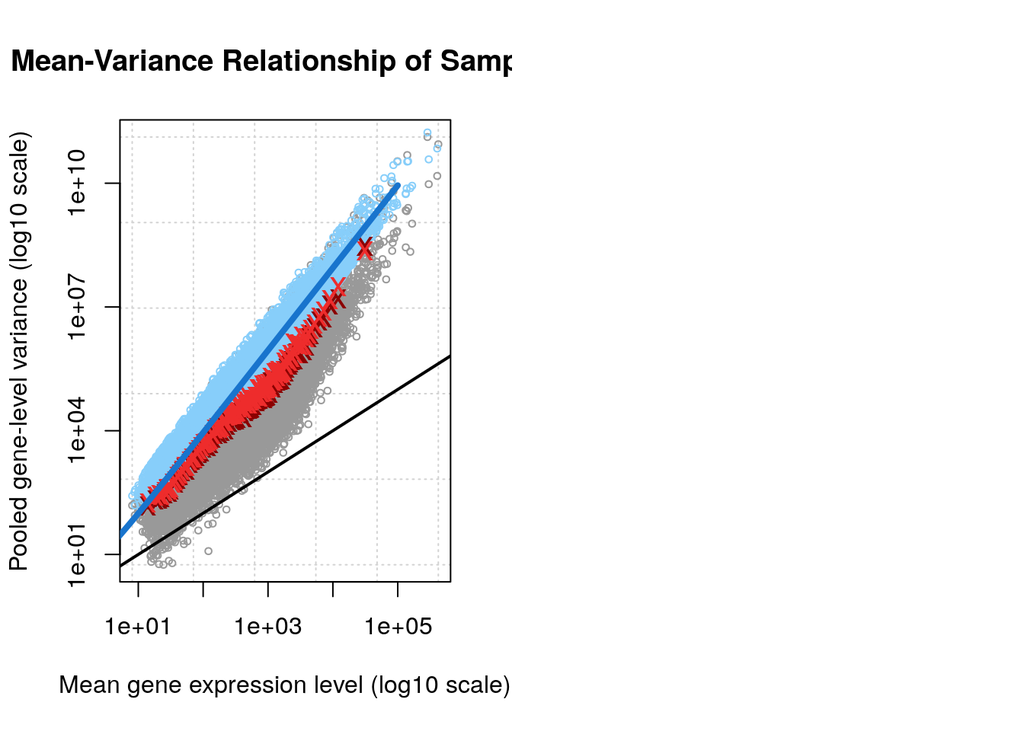

```r
#Separate the area to load 2 graphs
par(mfrow= c(1,2))
plotMeanVar(dispersion,
            show.raw.vars = TRUE,
            show.tagwise.vars=TRUE,
            NBline=TRUE,
            show.ave.raw.vars = TRUE,
            show.binned.common.disp.vars = TRUE,
            main = "Mean-Variance Relationship of Samples")
```

### Identifier mapping

- Commonly, data generation work with different identifiers
- I am going to use Esembl to mapp human gene

**Biomart**

- Important to working with up to date annotations and the right versions

```r
#Connect to ensembl mart and limit to human datasets
#Using grch37 because I keep get error when using most updated ensembl
ensembl <- useMart("ensembl", dataset = "hsapiens_gene_ensembl", host="grch37.ensembl.org")
```

**Converting Human Ensembl Gene Ids to HGNC symbols**

- Attribute: Ensembl gene Ids and HGNC symbols
- Filter: Ensembl gene ids
- Values: Ensembl gene ids

```r
#Filter
biomart_human_filters <- listFilters(ensembl)                  #Will go with ensembl_gene_id_version since my dataset contain version
kable(biomart_human_filters[
  grep(biomart_human_filters$name,pattern="ensembl"),],
      format="html")
```

|  | name | description |
| --- | --- | --- |
| 14 | with_clone_based_ensembl_gene | With Clone-based (Ensembl) gene ID(s) |
| 15 | with_clone_based_ensembl_transcript | With Clone-based (Ensembl) transcript ID(s) |
| 63 | ensembl_gene_id | Gene stable ID(s) [e.g. ENSG00000000003] |
| 64 | ensembl_gene_id_version | Gene stable ID(s) with version [e.g. ENSG00000000003.10] |
| 65 | ensembl_transcript_id | Transcript stable ID(s) [e.g. ENST00000000233] |
| 66 | ensembl_transcript_id_version | Transcript stable ID(s) with version [e.g. ENST00000000233.5] |
| 67 | ensembl_peptide_id | Protein stable ID(s) [e.g. ENSP00000000233] |
| 68 | ensembl_peptide_id_version | Protein stable ID(s) with version [e.g. ENSP00000000233.5] |
| 69 | ensembl_exon_id | Exon ID(s) [e.g. ENSE00000327880] |
| 75 | clone_based_ensembl_gene | Clone-based (Ensembl) gene ID(s) [e.g. AB019440.1] |
| 76 | clone_based_ensembl_transcript | Clone-based (Ensembl) transcript ID(s) [e.g. AB019440.1-201] |

```r
#Attributes
kable(searchAttributes(mart = ensembl, 'hgnc') , format="html") #Will go with hgnc_symbol
```

|  | name | description | page |
| --- | --- | --- | --- |
| 62 | hgnc_id | HGNC ID | feature_page |
| 63 | hgnc_symbol | HGNC symbol | feature_page |
| 64 | hgnc_trans_name | HGNC transcript name ID | feature_page |

```r
#Check to see if cell_id_conversion file exists
conversion_stash <- "cell_id_conversion.rds"
if(file.exists(conversion_stash)){
  cell_id_conversion <- readRDS(conversion_stash)
}else{
  cell_id_conversion <- getBM(attributes =
                              c("ensembl_gene_id", "hgnc_symbol"),
                              filters = c("ensembl_gene_id"),
                              values = factor(cell_exp_filtered$ensembl_gene_id),  #Values is first colum of my expression matrix
                              mart = ensembl)
  saveRDS(cell_id_conversion, conversion_stash)
}
```

**Difference between the number of mappings we have and the number of rows in our normalized set**

```r
#Difference between number of mapping I have and number of rows in normalized set
#Does not directly shows that missing that many
nrow(normalized_counts) - nrow(cell_id_conversion)
```

```
## [1] 483
```

**Merge new identifier**

```r
#Merge the new identifier
normalized_counts_annot <- merge(cell_id_conversion, normalized_counts, by.x = 1, by.y = 0, all.y = TRUE)
kable(normalized_counts_annot[1:5,1:5],type = "html")
```

| ensembl_gene_id | hgnc_symbol | iPSC.A | iPSC.B | hASTRO.A |
| --- | --- | --- | --- | --- |
| ENSG00000000003 | TSPAN6 | 49.9718769 | 49.3636305 | 47.307659 |
| ENSG00000000419 | DPM1 | 68.2095759 | 40.3461140 | 35.223430 |
| ENSG00000000457 | SCYL3 | 5.3520520 | 6.4867941 | 9.453908 |
| ENSG00000000460 | C1orf112 | 33.0721909 | 15.1552454 | 6.251778 |
| ENSG00000000971 | CFH | 0.0290872 | 0.0290888 | 19.517745 |

**Number of missing identifiers**

```r
#Number of identifier are missing
ensembl_id_missing_gene <- normalized_counts_annot$ensembl_gene_id[
  which(is.na(normalized_counts_annot$hgnc_symbol))]
length(ensembl_id_missing_gene)
```

```
## [1] 489
```

```r
#Were there expression values that could not be mapped to current HUGO symbols?
#Yes. (489/16993) = 0.029. About 2.9% of my dataset miss identifiers.
```

**Table of gene that miss identifier as NA**

-ENSG00000002586 is gene that related Xg blood group [link](https://useast.ensembl.org/Homo_sapiens/Gene/Summary?g=ENSG00000002586;r=X:2691187-2741309) -ENSG00000124333 is gene that related to vesicle associated membrane protein [link](https://useast.ensembl.org/Homo_sapiens/Gene/Summary?g=ENSG00000124333;r=X:155881345-155943769) -Some of gene has NA or empty string for hgnc_symbol, which can be novel transcription or common gene. Therefore, I would like to keep these gene instead of remove the them

```r
kable(normalized_counts_annot[which(is.na(normalized_counts_annot$hgnc_symbol))[1:5],], type="html")
```

|  | ensembl_gene_id | hgnc_symbol | iPSC.A | iPSC.B | hASTRO.A | hASTRO.B | hASTRO.C | hASTRO.D | iPSC.C | iPSC.D |
| --- | --- | --- | --- | --- | --- | --- | --- | --- | --- | --- |
| 22 | ENSG00000002586.18_PAR_Y | NA | 4.537609 | 0 | 163.003665 | 142.398446 | 0 | 0 | 4.185702 | 0 |
| 4721 | ENSG00000124333.15_PAR_Y | NA | 11.518547 | 0 | 34.842224 | 38.707582 | 0 | 0 | 13.345715 | 0 |
| 9977 | ENSG00000167393.17_PAR_Y | NA | 23.677013 | 0 | 6.976069 | 6.336473 | 0 | 0 | 24.082949 | 0 |
| 10273 | ENSG00000168939.11_PAR_Y | NA | 2.588764 | 0 | 2.134753 | 2.341740 | 0 | 0 | 7.340143 | 0 |
| 10299 | ENSG00000169084.13_PAR_Y | NA | 10.994976 | 0 | 12.503555 | 13.981564 | 0 | 0 | 8.978027 | 0 |

**Table of gene that miss identifier as empty string**

-1292 of gene has empty string as hgnc_symbol

```r
#Identify number of gene with empty string as hgnc_symbol
nrow(normalized_counts_annot[which(nchar(normalized_counts_annot$hgnc_symbol)==0),])
```

```
## [1] 1292
```

- Some gene has empty string as hgnc_symbol
- ENSG00000005189 is gene of RNA exonuclease [link](https://useast.ensembl.org/Homo_sapiens/Gene/Summary?g=ENSG00000005189;r=16:20806429-20849668)
- ENSG00000073169 is gene of selenoprotein O [link](https://useast.ensembl.org/Homo_sapiens/Gene/Summary?g=ENSG00000073169;r=22:50200979-50217616)

```r
kable(normalized_counts_annot[which(nchar(normalized_counts_annot$hgnc_symbol)==0)[1:5],], type="html")
```

|  | ensembl_gene_id | hgnc_symbol | iPSC.A | iPSC.B | hASTRO.A | hASTRO.B | hASTRO.C | hASTRO.D | iPSC.C | iPSC.D |
| --- | --- | --- | --- | --- | --- | --- | --- | --- | --- | --- |
| 77 | ENSG00000005189 |  | 4.014039 | 7.330368 | 2.325356 | 2.548364 | 3.984115 | 4.028962 | 5.975241 | 8.500098 |
| 1084 | ENSG00000073169 |  | 6.922763 | 8.842984 | 12.198590 | 8.884837 | 13.157623 | 13.901732 | 9.342000 | 8.024568 |
| 1595 | ENSG00000088899 |  | 34.148419 | 44.331275 | 21.042569 | 26.103512 | 14.396381 | 14.990641 | 41.523373 | 42.024962 |
| 1703 | ENSG00000091436 |  | 29.436286 | 21.060264 | 43.686202 | 67.876019 | 161.708191 | 143.844815 | 34.941508 | 26.362193 |
| 1764 | ENSG00000093100 |  | 2.036107 | 6.574060 | 36.443289 | 6.887470 | 7.968230 | 14.264702 | 4.610338 | 3.952843 |

**Identify different ensembl gene ids with duplicate HUGO gene symbol**

```r
#Collect all the duplicate of hgnc_symbol
hugoDuplicated <- normalized_counts_annot[duplicated(normalized_counts_annot$hgnc_symbol), 1:2]

#Collect all the non empty string for hgnc_synbol
hugoEmptyDuplicated <- hugoDuplicated[!(nchar(hugoDuplicated$hgnc_symbol) == 0),]

#Collect all the non NA for hgnc_synbol
nohugoEmptyNADuplicated <- hugoEmptyDuplicated[!is.na(hugoEmptyDuplicated$hgnc_symbol),]
nohugoEmptyNADuplicated
```

```
##       ensembl_gene_id hgnc_symbol
## 16093 ENSG00000265354     TIMM23B
```

- Detect the possible duplicate
- Chekc the duplicate

```r
#Colect the TIMM23B from normalized_counts_annot dataset
normalized_counts_annot[which(normalized_counts_annot$hgnc_symbol == "TIMM23B"), 1:6]
```

```
##       ensembl_gene_id hgnc_symbol   iPSC.A   iPSC.B hASTRO.A hASTRO.B
## 13702 ENSG00000204152     TIMM23B 12.85656 17.16237 15.36260 11.39876
## 16093 ENSG00000265354     TIMM23B 76.26674 58.26479 52.98763 51.20834
```

- I got two different ensemble_gene_id # ENSG00000204152[link](https://useast.ensembl.org/Homo_sapiens/Gene/Summary?g=ENSG00000204152;r=10:49942049-49974850) # ENSG00000265354[link](https://useast.ensembl.org/Homo_sapiens/Gene/Summary?g=ENSG00000265354;r=10:45972489-46003742;t=ENST00000580018)
- ENSG00000265354 is translocase of inner mitochondrial membrane 23
- ENSG00000204152 is ranslocase of inner mitochondrial membrane 23 homolog B
- These indicates that both gene doing simlar job since one is homolog to other
- When I look at the gene count of each gene, there is more significant amoutn of gene count on ENSG00000265354 compare to homolog
- Since I do not think that this duplicate is would affect the data and not specific reason to remove it, I will just keep duplicate

```r
#Only remove gene with NA in hgnc_symbol
finalized_dataset <- normalized_counts_annot
head(finalized_dataset)
```

```
##   ensembl_gene_id hgnc_symbol      iPSC.A      iPSC.B  hASTRO.A  hASTRO.B
## 1 ENSG00000000003      TSPAN6 49.97187691 49.36363053 47.307659 36.538029
## 2 ENSG00000000419        DPM1 68.20957588 40.34611405 35.223430 32.577734
## 3 ENSG00000000457       SCYL3  5.35205201  6.48679411  9.453908  8.850399
## 4 ENSG00000000460    C1orf112 33.07219095 15.15524544  6.251778  7.955028
## 5 ENSG00000000971         CFH  0.02908724  0.02908876 19.517745 13.017319
## 6 ENSG00000001036       FUCA2 35.95182763 58.84656721 54.741175 57.407064
##    hASTRO.C  hASTRO.D     iPSC.C      iPSC.D
## 1 38.334551 48.529023 41.0380737 68.83296439
## 2 36.694033 31.360565 60.4500229 36.19971961
## 3 10.914466  9.546098  7.1278251  6.71686095
## 4  7.265151  8.965347 24.9322222 25.53001572
## 5 46.235820 34.699885  0.1213247  0.05944125
## 6 85.039090 88.056402 37.7319762 60.03565979
```

```r
#Number of row in finlaized dataset
nrow(finalized_dataset)
```

```
## [1] 16999
```

### Final Coverage

```r
#Save filnalized data in text format
write.table(finalized_dataset, file = "Cell_expression.txt", sep = "\t")
```

### Assignment2

### Introduction

- I got filtered out data of RNAseq from assignment 1. In assignment, I will multiple statistical methods with threshold to collect the differentially expressed genes, either up or down regulated, in text format. Then, plot heat map and other plot methods to see the result and interpret the result with papers.

**Install require packages**

```r
if (!requireNamespace("colorRamps", quietly=TRUE)) {
  install.packages("colorRamps")
}
if (!requireNamespace("doBy", quietly=TRUE)) {
  install.packages("doBy")
}
if (!requireNamespace("gprofiler2", quietly=TRUE)) {
  install.packages("gprofiler2")
}
```

**Load library**

```r
#List of packages that need to be active for this project
library(GEOmetadb)
library(knitr)
library(tidyr)
library(biomaRt)
library(edgeR)
library(BiocGenerics)
library(ComplexHeatmap)
library(circlize)
library(colorRamps)
library(dplyr)
library(doBy)
library(gprofiler2)
library(kableExtra)
library(limma)
```

**Load the data**

```r
#Load data from Assignment 1
normalized_count_data <- read.table("Cell_expression.txt",
                                    header = TRUE,
                                    sep = "\t",
                                    stringsAsFactors = FALSE,
                                    check.names = FALSE)

#Read first five data with 5 columns
kable(normalized_count_data[1:5,1:5], type="html") %>%
  kable_styling(bootstrap_options = "striped", full_width = F)
```

| ensembl_gene_id | hgnc_symbol | iPSC.A | iPSC.B | hASTRO.A |
| --- | --- | --- | --- | --- |
| ENSG00000000003 | TSPAN6 | 49.9718769 | 49.3636305 | 47.307659 |
| ENSG00000000419 | DPM1 | 68.2095759 | 40.3461140 | 35.223430 |
| ENSG00000000457 | SCYL3 | 5.3520520 | 6.4867941 | 9.453908 |
| ENSG00000000460 | C1orf112 | 33.0721909 | 15.1552454 | 6.251778 |
| ENSG00000000971 | CFH | 0.0290872 | 0.0290888 | 19.517745 |

### New normalization to data for heatmap

```r
#Normalize the data
normalized_count_data %>%
  mutate_at(vars(-ensembl_gene_id, -hgnc_symbol), funs(.+1)) %>%
  mutate_at(vars(-ensembl_gene_id, -hgnc_symbol), funs(log2(.))) -> new_normalized_count_data

#Remove any duplicate ensembl_gene_id
new_normalized_count_data <- new_normalized_count_data[!duplicated(new_normalized_count_data$ensembl_gene_id),]
```

```r
#Check
kable(new_normalized_count_data[1:10,], type="html")%>%
  kable_styling(bootstrap_options = "striped", full_width = F)
```

| ensembl_gene_id | hgnc_symbol | iPSC.A | iPSC.B | hASTRO.A | hASTRO.B | hASTRO.C | hASTRO.D | iPSC.C | iPSC.D |
| --- | --- | --- | --- | --- | --- | --- | --- | --- | --- |
| ENSG00000000003 | TSPAN6 | 5.6716296 | 5.6543104 | 5.594180 | 5.230281 | 5.297725 | 5.630202 | 5.3936247 | 6.1258363 |
| ENSG00000000419 | DPM1 | 6.1128998 | 5.3696798 | 5.178851 | 5.069433 | 5.236264 | 5.016165 | 5.9413416 | 5.2172198 |
| ENSG00000000457 | SCYL3 | 2.6672227 | 2.9043481 | 3.385970 | 3.300182 | 3.574642 | 3.398637 | 3.0228694 | 2.9480141 |
| ENSG00000000460 | C1orf112 | 5.0905228 | 4.0139308 | 2.858335 | 3.162698 | 3.047041 | 3.316920 | 4.6966739 | 4.7295536 |
| ENSG00000000971 | CFH | 0.0413653 | 0.0413674 | 4.358800 | 3.809138 | 5.561809 | 5.157847 | 0.1652041 | 0.0833036 |
| ENSG00000001036 | FUCA2 | 5.2075738 | 5.9031966 | 5.800671 | 5.868071 | 6.426920 | 6.476647 | 5.2754532 | 5.9315805 |
| ENSG00000001084 | GCLC | 6.0318414 | 5.2893284 | 4.361478 | 4.632048 | 4.755631 | 4.598725 | 5.7067888 | 5.6577783 |
| ENSG00000001167 | NFYA | 5.7438846 | 5.3461439 | 5.036974 | 4.741960 | 5.222099 | 5.389108 | 5.8524971 | 5.7514902 |
| ENSG00000001460 | STPG1 | 2.9700256 | 3.4449558 | 3.563921 | 3.891790 | 3.691407 | 3.274257 | 3.3576937 | 3.8152756 |
| ENSG00000001461 | NIPAL3 | 3.5596589 | 3.7051759 | 6.746265 | 7.702369 | 5.860883 | 5.709398 | 3.7991991 | 3.9819321 |

**Numerical matrix**

```r
#Numerical matrix for heatmap
heatmap_matrix <- new_normalized_count_data[,3:ncol(new_normalized_count_data)]

#Assign rowname by ensemble_gene_id
rownames(heatmap_matrix) <- make.names(new_normalized_count_data$ensembl_gene_id, unique=TRUE)

#Assign colnames by gene names
colnames(heatmap_matrix) <- colnames(new_normalized_count_data[,3:ncol(new_normalized_count_data)])
```

### Difference in gene expression

- According from original paper CD44 is high expression in astrocyte. Therefore, I choose CD44 as gene of interest (Domenico et al. 2019).
- CD44 3 time more expressed in hCOM_ASTRO, hASTRO_CT, hASTRO_PD

```r
#Separate group based on cell type
sample_group_hASTRO <- grep(colnames(new_normalized_count_data),
                                pattern = "^hASTRO")
sample_group_iPSC <- grep(colnames(new_normalized_count_data),
                                pattern = "^iPSC")

#Set gene of interest as CD44, astrocyte specific gene
gene_of_interest <- which(new_normalized_count_data$hgnc_symbol == "CD44")
```

- CD44 expression in astrocyte

```r
#CD44 expression in astrocyte
cd44_hASTRO_samples <- t(new_normalized_count_data[gene_of_interest, sample_group_hASTRO])
colnames(cd44_hASTRO_samples) <- c("hASTRO")
cd44_hASTRO_samples
```

```
##             hASTRO
## hASTRO.A  9.595710
## hASTRO.B 10.634787
## hASTRO.C  9.609827
## hASTRO.D  9.328314
```

- CD44 expression in iPSC, around 3 times lower compare to CD44 expression in astrocyte

```r
#CD44 expression in iPSC
cd44_iPSC_samples <- t(new_normalized_count_data[gene_of_interest, sample_group_iPSC])
colnames(cd44_iPSC_samples) <- c("iPSC")
cd44_iPSC_samples
```

```
##            iPSC
## iPSC.A 3.869163
## iPSC.B 4.409104
## iPSC.C 3.611471
## iPSC.D 4.071366
```

- Use simple t.test compare this individual gene
- Null hypothesis of the two sample t-test is that there is no difference in means of each sample
- Assume both samples are normally distributed

```r
#Run t test of CD44 expression of astrocyte and ipsc
t.test(x=t(cd44_hASTRO_samples), y=t(cd44_iPSC_samples))
```

```
##
##  Welch Two Sample t-test
##
## data:  t(cd44_hASTRO_samples) and t(cd44_iPSC_samples)
## t = 17.381, df = 4.8336, p-value = 1.524e-05
## alternative hypothesis: true difference in means is not equal to 0
## 95 percent confidence interval:
##  4.934831 6.668936
## sample estimates:
## mean of x mean of y
##  9.792159  3.990276
```

- CD44 expression in astrocyte

```r
#CD44 expression in astrocyte after t test
cd44_hASTRO_samples <- t(new_normalized_count_data[gene_of_interest, sample_group_hASTRO])
colnames(cd44_hASTRO_samples) <- c("hASTRO")
cd44_hASTRO_samples
```

```
##             hASTRO
## hASTRO.A  9.595710
## hASTRO.B 10.634787
## hASTRO.C  9.609827
## hASTRO.D  9.328314
```

- CD44 expression in iPSC
- CD44 3 time more expressed in differentiated astrocyte

```r
#CD44 expression in iPSC after t test
cd44_iPSC_samples <- t(new_normalized_count_data[gene_of_interest, sample_group_iPSC])
colnames(cd44_iPSC_samples) <- c("iPSC")
cd44_iPSC_samples
```

```
##            iPSC
## iPSC.A 3.869163
## iPSC.B 4.409104
## iPSC.C 3.611471
## iPSC.D 4.071366
```

**Model**

- Different type of cells, either iPSC or hASTRO will contribute the difference
- There will be difference within patient (same cell type), but it would be small

```r
#Create data frame that has separate column for patient and cell type based on name of samples
samples <- data.frame(
           lapply(colnames(new_normalized_count_data)[3:ncol(new_normalized_count_data)],
           FUN=function(x){
             unlist(strsplit(x, split = "\\."))[c(1,2)]})) #Separate based on "." and put in column 1 and 2

#Use columns name from new_normalized_count_data
colnames(samples) <- colnames(new_normalized_count_data)[3:ncol(new_normalized_count_data)]

#Separate columns based on cell type and patient
rownames(samples) <- c("cell_type", "patient")
samples <- data.frame(t(samples))

#Show the table
samples
```

```
##          cell_type patient
## iPSC.A        iPSC       A
## iPSC.B        iPSC       B
## hASTRO.A    hASTRO       A
## hASTRO.B    hASTRO       B
## hASTRO.C    hASTRO       C
## hASTRO.D    hASTRO       D
## iPSC.C        iPSC       C
## iPSC.D        iPSC       D
```

### Linear model

- Create a design matrix, which need to create linear model

```r
#Model design based on samples cell type
model_design <- model.matrix(~samples$cell_type)

#Show the table
kable(model_design, type="html") %>%
  kable_styling(bootstrap_options = "striped", full_width = F)
```

| (Intercept) | samples$cell_typeiPSC |
| --- | --- |
| 1 | 1 |
| 1 | 1 |
| 1 | 0 |
| 1 | 0 |
| 1 | 0 |
| 1 | 0 |
| 1 | 1 |
| 1 | 1 |

- Create data matrix
- Website that explain about assayData (n.d.)

```r
#Create matrix that contain infomration of normalized data from column 3 to end
expressionMatrix <- as.matrix(new_normalized_count_data[,3:ncol(new_normalized_count_data)])

#Ensemble gene as row name
rownames(expressionMatrix) <- new_normalized_count_data$ensembl_gene_id

#Set column name based on normalized data
colnames(expressionMatrix) <- colnames(new_normalized_count_data)[3:ncol(new_normalized_count_data)]

#Create minimal set by using assayData, which must contain a matrix expression with rows and representing features and columnes representing samples
minimalSet <- ExpressionSet(assayData=expressionMatrix)

#Fit data to the above model
fit <- lmFit(minimalSet, model_design)
```

- Apply empirical Bayes to compute differential expression for the above described model
- The parameter trend=TRUE is specific to RNA-seq data
- I use BH threshold to reduce the false discovery rate, which will avoid type 1 error. The other adjust method are too extreme that either increase false negative or false positive for this data. (n.d.)

```r
#Apply empitical bayes to fit data
ebayes_fit <- eBayes(fit, trend=TRUE)

#Collect the data that adjust method, which is BH, applied
topfit <- topTable(ebayes_fit,
                   coef=ncol(model_design),
                   adjust.method = "BH",
                   number = nrow(expressionMatrix))

#Merge hgnc names to topfit table
output_hits <- merge(new_normalized_count_data[,1:2],
                     topfit,
                     by.y = 0, by.x = 1,
                     all.y = TRUE)
#Sort by pvalue
output_hits <- output_hits[order(output_hits$P.Value),]
#Table

kable(output_hits[1:10,], type="html") %>%
  kable_styling(bootstrap_options = "striped", full_width = F)
```

|  | ensembl_gene_id | hgnc_symbol | logFC | AveExpr | t | P.Value | adj.P.Val | B |
| --- | --- | --- | --- | --- | --- | --- | --- | --- |
| 11052 | ENSG00000174099 | MSRB3 | -5.728253 | 4.526069 | -31.58745 | 0 | 2.9e-06 | 13.74448 |
| 9937 | ENSG00000167123 | CERCAM | -4.750546 | 5.418317 | -29.91980 | 0 | 2.9e-06 | 13.39331 |
| 8635 | ENSG00000159216 | RUNX1 | -6.816623 | 4.104574 | -28.95348 | 0 | 2.9e-06 | 13.17504 |
| 4058 | ENSG00000117228 | GBP1 | -5.720482 | 3.007139 | -27.50517 | 0 | 2.9e-06 | 12.82560 |
| 13558 | ENSG00000198796 | ALPK2 | -7.574717 | 4.591906 | -27.04401 | 0 | 2.9e-06 | 12.70833 |
| 4224 | ENSG00000119242 | CCDC92 | -5.380433 | 3.097919 | -26.99704 | 0 | 2.9e-06 | 12.69621 |
| 9741 | ENSG00000166147 | FBN1 | -6.899814 | 7.454708 | -26.52532 | 0 | 2.9e-06 | 12.57275 |
| 9042 | ENSG00000162849 | KIF26B | -5.353285 | 3.623001 | -26.33549 | 0 | 2.9e-06 | 12.52213 |
| 3169 | ENSG00000109099 | PMP22 | -7.085657 | 4.996938 | -25.57108 | 0 | 3.2e-06 | 12.31267 |
| 7668 | ENSG00000148516 | ZEB1 | -7.011617 | 3.941617 | -25.26380 | 0 | 3.2e-06 | 12.22585 |

- 10741 of genes pass the threshold p-value <0.05.

```r
length(which(output_hits$P.Value < 0.05))
```

```
## [1] 10741
```

- 9869 genes pass correction

```r
length(which(output_hits$adj.P.Val < 0.05))
```

```
## [1] 9869
```

### Multiple Hypothesis test

- When number of tests performed increases, a false positive might increase
- Multiple hypothesis testing will come up for differential expression, pathways analysis, and for any analysis where there are multiple tests being performed
- Control for family-wise error rate or for false discovery rate

```r
#Create a design matrix
model_design_pat <- model.matrix(
  ~samples$patient + samples$cell_type) #Design matrix based on cell type and sample group
#Check the matrix
table_model_design_pat <- as.data.frame(model_design_pat)
table_model_design_pat
```

```
##   (Intercept) samples$patientB samples$patientC samples$patientD
## 1           1                0                0                0
## 2           1                1                0                0
## 3           1                0                0                0
## 4           1                1                0                0
## 5           1                0                1                0
## 6           1                0                0                1
## 7           1                0                1                0
## 8           1                0                0                1
##   samples$cell_typeiPSC
## 1                     1
## 2                     1
## 3                     0
## 4                     0
## 5                     0
## 6                     0
## 7                     1
## 8                     1
```

- fit data to the model_design_cell

```r
fit_pat <- lmFit(minimalSet, model_design_pat)
```

- Apply empirical Bayes to compute differential expression for the above described model

```r
#The parameter trend = TRUE is specific to RND-seq data
ebayes_fit_pat <- eBayes(fit_pat, trend = TRUE)
topfit_pat <- topTable(ebayes_fit_pat,
                       coef = ncol(model_design_pat),
                       adjust.method = "BH",
                       number = nrow(expressionMatrix))

#Merge hgnc names to topfit table
output_hits_pat <- merge(new_normalized_count_data[, 1:2],
                         topfit_pat, by.y=0, by.x=1, all.y=TRUE)
#Sort by pvalue
output_hits_pat <- output_hits_pat[order(output_hits_pat$P.Value),]

#Check
kable(output_hits_pat[1:10,], type="html")%>%
  kable_styling(bootstrap_options = "striped", full_width = F)
```

|  | ensembl_gene_id | hgnc_symbol | logFC | AveExpr | t | P.Value | adj.P.Val | B |
| --- | --- | --- | --- | --- | --- | --- | --- | --- |
| 190 | ENSG00000008441 | NFIX | -7.286118 | 4.519172 | -38.40576 | 0e+00 | 0.0001382 | 9.189616 |
| 8635 | ENSG00000159216 | RUNX1 | -6.816623 | 4.104574 | -37.51832 | 0e+00 | 0.0001382 | 9.113968 |
| 4272 | ENSG00000119681 | LTBP2 | -7.623419 | 6.060059 | -37.04555 | 0e+00 | 0.0001382 | 9.072156 |
| 2506 | ENSG00000103888 | KIAA1199 | -6.094511 | 6.036422 | -36.64151 | 0e+00 | 0.0001382 | 9.035557 |
| 509 | ENSG00000041982 | TNC | -6.931249 | 7.216754 | -32.52452 | 1e-07 | 0.0002231 | 8.611453 |
| 9741 | ENSG00000166147 | FBN1 | -6.899814 | 7.454708 | -31.53934 | 1e-07 | 0.0002231 | 8.494229 |
| 399 | ENSG00000026508 | CD44 | -5.801883 | 6.891218 | -29.80103 | 1e-07 | 0.0002300 | 8.269947 |
| 11052 | ENSG00000174099 | MSRB3 | -5.728253 | 4.526069 | -29.45561 | 1e-07 | 0.0002300 | 8.222518 |
| 11294 | ENSG00000176046 | NUPR1 | -6.668329 | 3.755843 | -29.29102 | 1e-07 | 0.0002300 | 8.199566 |
| 9477 | ENSG00000164694 | FNDC1 | -6.484058 | 4.635066 | -27.55935 | 2e-07 | 0.0002938 | 7.943458 |

```r
length(which(output_hits_pat$P.Value < 0.05))
```

```
## [1] 10263
```

```r
length(which(output_hits_pat$adj.P.Value < 0.05))
```

```
## [1] 0
```

- Use Quasi to calculate differential expression genes

```r
#Set up edgeR objects
edge_obj = DGEList(counts=filtered_data_matrix, group=samples$cell_type)

#Estimate Dispersion - our model design
edge_obj <- estimateDisp(edge_obj, model_design_pat)

#Fit the model
fit <- glmQLFit(edge_obj, model_design_pat)
```

- Calculate differential expression using the Quasi likelihood model

```r
qlf.iPSC_vs_hASTRO <- glmQLFTest(fit, coef='samples$cell_typeiPSC')

#plot the table
topTags(qlf.iPSC_vs_hASTRO)
```

```
## Coefficient:  samples$cell_typeiPSC
##                      logFC   logCPM         F       PValue          FDR
## ENSG00000147883  -6.782249 5.561304 1157.7616 8.891990e-08 0.0009823517
## ENSG00000176046  -8.428381 5.999789 1054.9682 1.156184e-07 0.0009823517
## ENSG00000119681  -7.686570 8.873231  762.0897 2.893571e-07 0.0012926821
## ENSG00000117226  -8.850286 4.040764  708.0475 3.559903e-07 0.0012926821
## ENSG00000174099  -5.977585 6.273533  682.7683 3.943740e-07 0.0012926821
## ENSG00000000971  -8.535409 3.672329  575.9320 6.366409e-07 0.0012926821
## ENSG00000164106 -10.275179 5.457191  557.4834 6.976773e-07 0.0012926821
## ENSG00000162849  -6.110159 5.183740  533.9295 7.876935e-07 0.0012926821
## ENSG00000159216  -7.965852 6.387569  533.5658 7.892034e-07 0.0012926821
## ENSG00000214336   8.112168 3.740764  530.2342 8.032190e-07 0.0012926821
```

- Grab all the results

```r
qlf_output_hits <- topTags(qlf.iPSC_vs_hASTRO,
                           sort.by = "PValue",
                           n = nrow(new_normalized_count_data),
                           adjust.method = "BH")  #Use BH as adjust method for this assignment
```

```r
length(which(qlf_output_hits$table$PValue < 0.05))
```

```
## [1] 10217
```

- 9042 genes pass the correction

```r
length(which(qlf_output_hits$table$FDR < 0.05))
```

```
## [1] 9042
```

### Heat map

- Heat map of top hits using the Quasi likelihood model
- Heat map is graph that translate numbers into scale of color
- Good for summary of what are data looks like
- Same cell_type cluster together in heat map as we can see clear block of gene expression between iPSC and astrocyte.
- This can happen because author need to provide specific transcription factor to differentiate fibroblast to iPSC and iPSC to astrocyte. Since those specific transcription factors will significantly up or down regulated, the cluster would be more

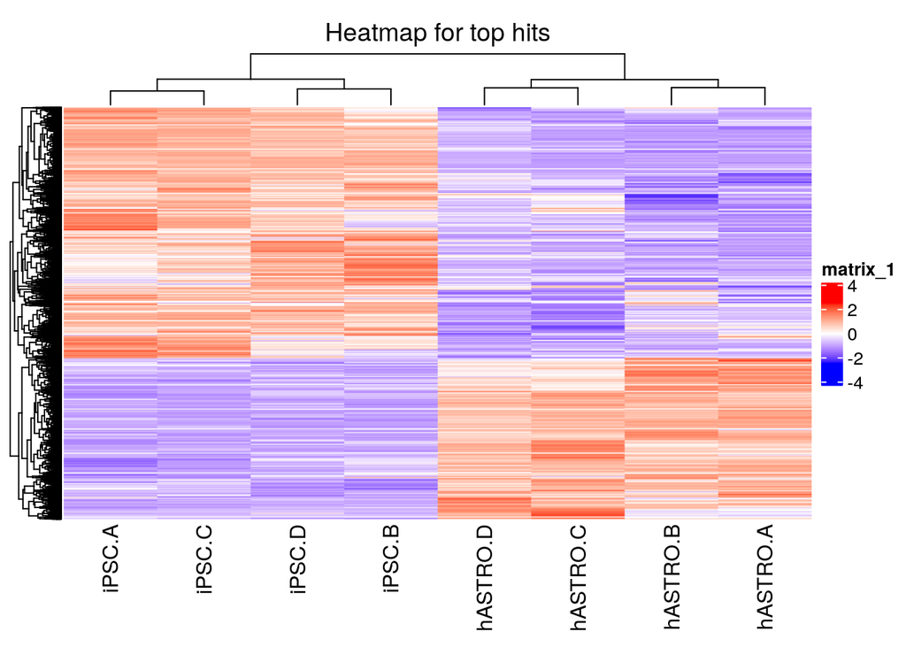

```r
#Set top hit
top_hits <- rownames(qlf_output_hits$table)[output_hits_pat$P.Value<0.05]
#Set heatmap matrix tophits
heatmap_matrix_tophits <- t(
  scale(t(heatmap_matrix[which(rownames(heatmap_matrix) %in% top_hits),])))

#Sorth the column by cell type
#Organize by cell type
heatmap_matrix_tophits <- heatmap_matrix_tophits[, c(grep(colnames(heatmap_matrix_tophits), pattern = "^iPSC"),
                                                     grep(colnames(heatmap_matrix_tophits), pattern = "^hASTRO"))]

if(min(heatmap_matrix_tophits) == 0){
    heatmap_col = colorRamp2(c( 0, max(heatmap_matrix_tophits)), #if no negative value in heatmap matrix,
                             c( "white", "red"))                 #use white and red color
  } else {
    heatmap_col = colorRamp2(c(min(heatmap_matrix_tophits), 0, max(heatmap_matrix_tophits)), c("blue", "white", "red")) #blue, white, red if heatmap matrix contain negative value
  }
#Plot
current_heatmap <- Heatmap(as.matrix(heatmap_matrix_tophits),
                           cluster_rows = TRUE,
                           cluster_columns = TRUE,
                           show_row_dend = TRUE,
                           show_column_dend = TRUE,
                           col = heatmap_col,
                           show_column_names = TRUE,
                           show_row_names = FALSE,
                           show_heatmap_legend = TRUE,
                           column_title  = "Heatmap for top hits")
current_heatmap
```

### Enrichment Analysis

```r
#Calculate normalization factors
edge_objs <- calcNormFactors(edge_obj)

#Dit model
fits <- glmQLFit(edge_objs, model_design_pat)

#calculate differential expression
qlf.hiPSC_vs_hASTRO <- glmQLFTest(fits, coef='samples$cell_typeiPSC')
```

- Get all the result

```r
qlf_output_hit <- topTags(qlf.hiPSC_vs_hASTRO,sort.by = "PValue",
                          n = nrow(new_normalized_count_data),
                          adjust.method = "BH")
```

- 9977 genes pass the threshold p-value < 0.05

```r
length(which(qlf_output_hit$table$PValue < 0.05))
```

```
## [1] 9977
```

- 8684 genes pass correction

```r
length(which(qlf_output_hit$table$FDR < 0.05))
```

```
## [1] 8684
```

- Output top

```r
topTags(qlf.hiPSC_vs_hASTRO)
```

```
## Coefficient:  samples$cell_typeiPSC
##                      logFC   logCPM         F       PValue          FDR
## ENSG00000147883  -7.072359 5.561304 1356.5603 6.228246e-08 0.0006348592
## ENSG00000176046  -8.724601 5.999789 1271.3433 7.472008e-08 0.0006348592
## ENSG00000117226  -9.127679 4.040764  805.1695 2.688471e-07 0.0011341151
## ENSG00000119681  -7.979054 8.873231  729.4311 3.544762e-07 0.0011341151
## ENSG00000174099  -6.269017 6.273533  663.8840 4.612822e-07 0.0011341151
## ENSG00000000971  -8.831714 3.672329  651.8760 4.854351e-07 0.0011341151
## ENSG00000162849  -6.402484 5.183740  640.2579 5.104639e-07 0.0011341151
## ENSG00000159216  -8.260542 6.387569  610.8815 5.820706e-07 0.0011341151
## ENSG00000164106 -10.535707 5.457191  604.0468 6.006612e-07 0.0011341151
## ENSG00000103888  -6.315549 8.034202  554.7927 7.617441e-07 0.0011660431
```

- 4930 genes are up regulated (downregulated when differentiate iPSC to astrocyte)

```r
length(which(qlf_output_hit$table$PValue < 0.05 & qlf_output_hit$table$logFC > 0))
```

```
## [1] 4930
```

- 5047 genes are down regulated (upregulated when differentiate iPSC to astrocyte)

```r
length(which(qlf_output_hit$table$PValue < 0.05 & qlf_output_hit$table$logFC < 0))
```

```
## [1] 5047
```

- Create thresholded lists of genes
- The RNAseq data has been reversed. I want to see the expression difference after differentiate the astrocyte. Therefore, I will have upregulated_gene as downregulated file and vice versa.

```r
#merge gene names with the top hits
qlf_output_hits_withgn <- merge(new_normalized_count_data[,1:2],qlf_output_hit, by.x=1, by.y = 0)
qlf_output_hits_withgn[,"rank"] <- -log(qlf_output_hits_withgn$PValue,base =10) * sign(qlf_output_hits_withgn$logFC)
qlf_output_hits_withgn <- qlf_output_hits_withgn[order(qlf_output_hits_withgn$rank),]
downregulated_genes <- qlf_output_hits_withgn$hgnc_symbol[
  which(qlf_output_hits_withgn$PValue < 0.05            #downregulated when differentiate iPSC to astrocyte
             & qlf_output_hits_withgn$logFC > 0)]
upregulated_genes <- qlf_output_hits_withgn$hgnc_symbol[
  which(qlf_output_hits_withgn$PValue < 0.05
             & qlf_output_hits_withgn$logFC < 0)]      #upregulated when differentiate iPSC to astrocyte
write.table(x=downregulated_genes,
            file="cell_downregulated_genes.txt",sep = "\t",
            row.names = FALSE,col.names = FALSE,quote = FALSE)    #save as downregulated file
write.table(x=upregulated_genes,
            file="cell_upregulated_genes.txt",sep = "\t",
            row.names = FALSE,col.names = FALSE,quote = FALSE)   #save as upregulated file
```

### Volcanoplot

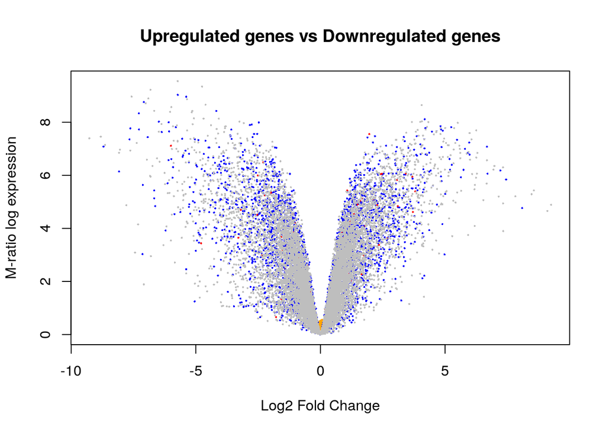

```r
#P values from data that apply multiple hypothesis testing
qlf_cell_model_pvalues <- data.frame(ensembl_id = rownames(qlf_output_hits$table),
                                     qlf_cell_pvalue=qlf_output_hits$table$PValue)

#downregulated when differentiate iPSC to astrocyte
downregulated_gene <- qlf_output_hits_withgn[which(qlf_output_hits_withgn$PValue < 0.05 & qlf_output_hits_withgn$logFC > 0),]
upregulated_gene <- qlf_output_hits_withgn[which(qlf_output_hits_withgn$PValue < 0.05 & qlf_output_hits_withgn$logFC < 0),]

#Plot for gene of interest CD44
ensembl_of_interest <- new_normalized_count_data$ensembl_gene_id[
                       which(new_normalized_count_data$hgnc_symbol == "CD44")]

#Downregulated gene ensembl_id
downregulated_gene <-  data.frame(ensembl_id = downregulated_gene$ensembl_gene_id)

#Upregualted gene ensembl_id
upregulated_gene <-  data.frame(ensembl_id = upregulated_gene$ensembl_gene_id)

qlf_cell_model_pvalues$colour <- "grey" #Grey for all genes
qlf_cell_model_pvalues$colour[upregulated_gene$ensembl_id] <- "red" #Red for upregulated
qlf_cell_model_pvalues$colour[downregulated_gene$ensembl_id] <- "blue" #Blue for downregulated
qlf_cell_model_pvalues$colour[qlf_cell_model_pvalues$ensembl_id==ensembl_of_interest] <- "orange" #Orange for gene of interest

volcanoplot(ebayes_fit,
            coef = ncol(ebayes_fit),
            ylab = "M-ratio log expression",
            cex = ifelse(qlf_cell_model_pvalues$colour == "orange", 2, 0.3),
            col = qlf_cell_model_pvalues$colour,
            main = "Upregulated genes vs Downregulated genes")
```

```r
#Check to make sure upregulated genes list contain the astrocyte specific gene
upregulated_genes_dataframe <- as.data.frame(upregulated_genes)
#List of gene that expressed in astrocyte
list_upregulated <- c(upregulated_genes_dataframe[upregulated_genes_dataframe == "CD44"],
                      upregulated_genes_dataframe[upregulated_genes_dataframe == "SOX9"],
                      upregulated_genes_dataframe[upregulated_genes_dataframe == "DIO2"])
#Remove NA
list_upregulated <- list_upregulated[!is.na(list_upregulated)]
list_upregulated
```

```
## [1] "CD44" "SOX9" "DIO2"
```

```r
#Check to make sure upregulated genes list contain the astrocyte specific gene
downregulated_genes_dataframe <- as.data.frame(downregulated_genes)
#List of gene that expressed in iPSC
list_downregulated <- c(downregulated_genes_dataframe[downregulated_genes_dataframe == "MYC"],
                      downregulated_genes_dataframe[downregulated_genes_dataframe == "NANOG"],
                      downregulated_genes_dataframe[downregulated_genes_dataframe == "SALL4"])
#Remove NA
list_downregulated <- list_downregulated[!is.na(list_downregulated)]
list_downregulated
```

```
## [1] "MYC"   "NANOG" "SALL4"
```

- I choose g:profiler because it update frequently and has graphical interface on website (user friendly).
- I use GO biological process (releases/2019-07-01), Reactome (annotations:ensembl classes: 2019-10-2), and WikiPathways (releases/ 2019-09-10). I use GO biological process because it provide framework and set of concept for describing the function of gene products of their outcome, which would be significantly differential gene expression of iPSC and astrocyte (n.d.). I use reactome because it is open source and peer-reviewed pathway database that is useful to analyze the pathway of significantly differential genes (n.d.). WikiPathways present model for pathway database and it is peer-reviewed. I use WikiPathway to compare to reactome (n.d.).
- I use Benjamini-Hochberg FDR as significance threshold with 0.05 as user threshold and term size as 5-200. For upregulated gene, I got 844 for GO biological process, 153 for Reactome, and 81 for WikiPathways. For downregulated gene, I got 538 for Go biological process, 252 for Reactome, and 24 for WikiPathway.
- For upregulated set of genes, I got top term as cell-substrate junction assembly (GO:0007044), transport to the golgi and subsequent modification (REAC:R-HSA-948021), and focal adhesion (WP:WP306). When I look threw list of term, mostly related about adhesion junction, IL signaling pathway, and vacuole organization and transportion. This makes sense since roles of astrocyte are regulate blood flow, homeostasis, and regulate synaptic transmission (Sofroniew and Vinters 2010).
- For downregulated set of genes, I got top terms as DNA-dependent DNA replication (GO:0006261), mitotic prometaphase (REAC:R-HSA-68877), and retinoblastoma gene in cancer (WP:WP2446). Terms are mostly related about DNA replication, mitosis, and telomere maintenance. This is true since iPSC has similar characteristic as embryonic stem cell, which needs to be able to proliferate and differentiate to different types of cell to grow into human (Vazin and Freed 2010).
- When I combined up and down regulated set of genes and run on gprofiler, I got top terms as DNA biosynthetic process (GO:0071897), mitotic prometaphas (REAC:R-HSA-68877), and retinoblastoma gene in cancer (WP:WP2446). Top terms are mostly similar to downregulated set of genes while low terms are mostly similar to upregulated set of genes. This might happen because the set of genes that expressed in iPSC (downregulated set of genes) are unique and specific while gene that expressed in ipsc-derived astrocyte (upregulated set of genes) are more general and might also expressed in iPSC at lower level.
- I save the geneset as csv format.
- For upregulated genesets, I save as upregulated-gene.csv
- For downregulated geneset, I save as downregulated_gene
- For whole list of differentially expressed geneset, I save as list_of_gene.csv

### Interpretation

- Over representation results support conclusions or mechanism discussed in the original paper. From original paper (Domenico et al. 2019), it shows with the heatmap transcriptomic profile of ipsc-derived astrocyte are silimar to asttrocyte than corresponding iPSC. Based on my heatmap, we can see that transcriptomic profile of ipsc-derived astrocyte is completely different from ipsc and similar within astrocytes. Author also mention about list of astrocyte specific genes, such as CD44, MLC1, and SOX9. These genes has been included in list of upregulated gene.
- According to Takahashi work’s, MYC, NANOG, and SALL4 are iPSC specific genes. This indicates that ipsc-derived astrocyte should downregulate these genes. I detect 3 genes in list of downregulated genes (Takahashi et al. 2008). Therefore, I can conclude ipsc downregulate ipsc specific gene and upregulate the astrocyte specific gene to become ipse-derived astrocyte.

### References

Domenico, Angelique di, Giulia Carola, Carles Calatayud, Meritxell Pons-Espinal, Juan Pablo Muñoz, Yvonne Richaud-Patin, Irene Fernandez-Carasa, et al. 2019. “Patient-Specific iPSC-Derived Astrocytes Contribute to Non-Cell-Autonomous Neurodegeneration in Parkinson’s Disease.” *Stem Cell Reports* 12 (2). Elsevier: 213–29.

Sofroniew, Michael V, and Harry V Vinters. 2010. “Astrocytes: Biology and Pathology.” *Acta Neuropathologica* 119 (1). Springer: 7–35.

Takahashi, Kazutoshi, Koji Tanabe, Mari Ohnuki, Megumi Narita, Tomoko Ichisaka, Kiichiro Tomoda, and Shinya Yamanaka. 2008. “Induction of Pluripotent Stem Cells from Adult Human Fibroblasts by Defined Factors.” *Obstetrical & Gynecological Survey* 63 (3). LWW: 153.

Vazin, Tandis, and William J Freed. 2010. “Human Embryonic Stem Cells: Derivation, Culture, and Differentiation: A Review.” *Restorative Neurology and Neuroscience* 28 (4). IOS Press: 589–603.

n.d. *ExpressionSet*. https://www.rdocumentation.org/packages/Biobase/versions/2.32.0/topics/ExpressionSet.

n.d. *Banjamini-Hochberg-Procedure*. https://www.statisticshowto.datasciencecentral.com/benjamini-hochberg-procedure/.

n.d. *Go Biological Process*. http://www.informatics.jax.org/vocab/gene_ontology/GO:0008150.

n.d. *Reactome*. https://reactome.org/".

n.d. *WikiPathways:About*. https://www.wikipathways.org/index.php/WikiPathways:About".